**Machine Learning for Mechanical Engineering**  
**Final Exam, Part 2**  
**Thursday, 06/09/2023, 09:00~11:00 PM**

TA: Jaejun Lee  
Instructor: Prof. Seungchul Lee  
http://iai.postech.ac.kr/  
Industrial AI Lab at POSTECH

# Problem 1 [10pt]

We want to use a multilayer perceptron to perform regression on nonlinearly distributed data in this problem.

[10pt] To find a regression curve, use MLP (or ANN) and then plot it with data. It is up to you to design your own network structure. Don't be concerned about your performance of the regression model.

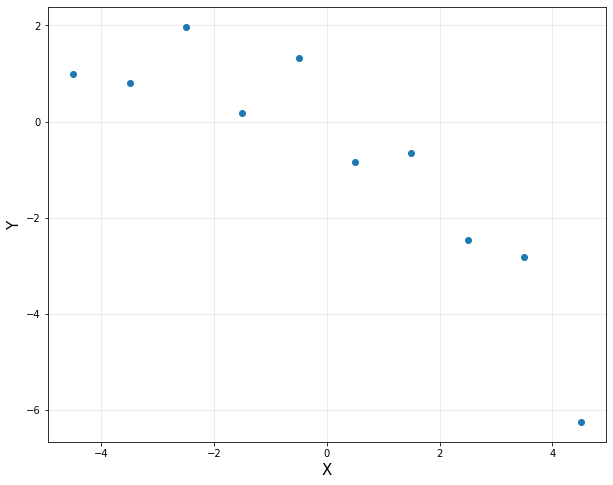

```python
import numpy as np
import matplotlib.pyplot as plt
from sklearn.neural_network import MLPRegressor
%matplotlib inline

# 10 data points
n = 10
x = np.linspace(-4.5, 4.5, 10).reshape(-1,1)
y = np.array([0.9819, 0.7973, 1.9737, 0.1838, 1.3180, -0.8361, -0.6591, -2.4701, -2.8122, -6.2512]).reshape(-1,1)

plt.figure(figsize = (10, 8))
plt.plot(x, y, 'o', label = 'Data')
plt.xlabel('X', fontsize = 15)
plt.ylabel('Y', fontsize = 15)
plt.grid(alpha = 0.3)
plt.show()
```

```python
## write your code here
#
```

# Problem 2 [20pt]

1) [5pt] Read the image and decompose the image using SVD (i.e., compute $U, \Sigma, V$).

Download [image](https://www.dropbox.com/s/js0t2o3n7htmkfi/postech_logo.jpg?dl=1)

```python
## write your code
#
```

2) [10pt] Compress the image using 5, 10, 20, 100, and 150 singular values, respectively.

```python
## write your code
#
```

3) [5pt] Determine how many sigular values are needed to compress the image and explain why. Do not worry about the color.

```python
## write the reason about your determination
#
```